| title: “Machine Learning Fit of Parameters of a Weight Lifting Exercise” |
| --- |
| author: “Mutsuji Takahashi” |
| date: “2021/6/27” |
| output: html_document |

## Abstract

A predictor was studied to predict a kind of weight lifting exercise. The dataset is divided to three dataset for training, testing and validation. Three prediction methods(Random forest(RF), Linear discriminant analysis(lda),Recursive Partitioning and Regression Trees(rpart)) were tried, Rf method was found to be the best using test dataset. The method was confirmed to be valid utilizing a dataset for validity.

## Exploratory analysis

The dataset was downloaded from coursera repository. The variables which include any NA’s were excluded for simplicity, as this was a starting level of analysis. The data were divided into three part in a proportion of 0.6, 0.2, 0.2 as training, testing and valid, respectively.

```r
dim(train0)
```

```
## [1] 19622   160
```

```r
dim(train);dim(test);dim(valid)
```

```
## [1] 11776    53
```

```
## [1] 3923   53
```

```
## [1] 3923   53
```

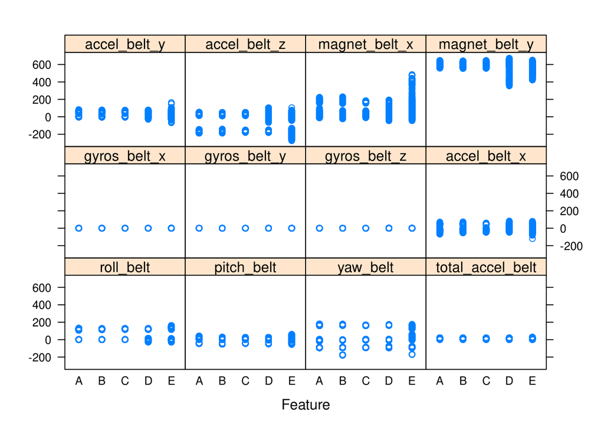

```r
featurePlot(x=train[,c(1:12)],y=train$classe)
```

## Analysis

Three prediction methods(Random forest(RF), Linear discriminant analysis(lda),Recursive Partitioning and Regression Trees(rpart)) were tried. The results were as follows:

### rpart

```r
fit_rpart$finalModel
```

```
## n= 11776
##
## node), split, n, loss, yval, (yprob)
##       * denotes terminal node
##
##  1) root 11776 8428 A (0.28 0.19 0.17 0.16 0.18)
##    2) roll_belt< 130.5 10778 7437 A (0.31 0.21 0.19 0.18 0.11)
##      4) pitch_forearm< -26.65 1052   41 A (0.96 0.039 0 0 0) *
##      5) pitch_forearm>=-26.65 9726 7396 A (0.24 0.23 0.21 0.2 0.12)
##       10) magnet_dumbbell_y< 432.5 8172 5887 A (0.28 0.18 0.24 0.19 0.11)
##         20) roll_forearm< 123.5 5043 3001 A (0.4 0.18 0.18 0.17 0.061) *
##         21) roll_forearm>=123.5 3129 2067 C (0.078 0.17 0.34 0.23 0.18) *
##       11) magnet_dumbbell_y>=432.5 1554  766 B (0.029 0.51 0.049 0.23 0.19) *
##    3) roll_belt>=130.5 998    7 E (0.007 0 0 0 0.99) *
```

```r
confusionMatrix(data=pred_rpart, reference=test$classe)
```

```
## Confusion Matrix and Statistics
##
##           Reference
## Prediction    A    B    C    D    E
##          A 1002  318  322  294  119
##          B   30  259   21  125   93
##          C   79  182  341  224  205
##          D    0    0    0    0    0
##          E    5    0    0    0  304
##
## Overall Statistics
##
##                Accuracy : 0.4859
##                  95% CI : (0.4701, 0.5016)
##     No Information Rate : 0.2845
##     P-Value [Acc > NIR] : < 2.2e-16
##
##                   Kappa : 0.3276
##
##  Mcnemar's Test P-Value : NA
##
## Statistics by Class:
##
##                      Class: A Class: B Class: C Class: D Class: E
## Sensitivity            0.8978  0.34124  0.49854   0.0000  0.42164
## Specificity            0.6249  0.91498  0.78697   1.0000  0.99844
## Pos Pred Value         0.4876  0.49053  0.33075      NaN  0.98382
## Neg Pred Value         0.9390  0.85272  0.88140   0.8361  0.88462
## Prevalence             0.2845  0.19347  0.17436   0.1639  0.18379
## Detection Rate         0.2554  0.06602  0.08692   0.0000  0.07749
## Detection Prevalence   0.5238  0.13459  0.26281   0.0000  0.07877
## Balanced Accuracy      0.7614  0.62811  0.64275   0.5000  0.71004
```

train:0.5095889  
test:0.4858527

### lda

```r
fit_lda$finalModel
```

```
## Call:
## lda(x, grouping = y)
##
## Prior probabilities of groups:
##         A         B         C         D         E
## 0.2843071 0.1935292 0.1744226 0.1638927 0.1838485
##
## Group means:
##   roll_belt pitch_belt   yaw_belt total_accel_belt gyros_belt_x gyros_belt_y
## A  59.04283  0.4512843 -12.590771         10.63351 -0.004599761   0.04015233
## B  66.55860 -0.5271435 -10.822900         11.30408 -0.003286529   0.04379114
## C  64.81847 -0.9919474  -7.319508         11.20010 -0.020272639   0.03827167
## D  61.02288  1.6140622 -17.202694         11.27979 -0.011953368   0.03668912
## E  74.90788  0.7491316  -4.756074         12.79076  0.003487298   0.03747806
##   gyros_belt_z accel_belt_x accel_belt_y accel_belt_z magnet_belt_x
## A   -0.1202748    -6.351254     28.82407    -62.23775      57.71535
## B   -0.1365204    -4.289601     32.45546    -75.73936      50.59368
## C   -0.1378724    -4.138267     31.13973    -70.98880      57.19572
## D   -0.1370674    -8.074611     30.42435    -69.21917      48.87409
## E   -0.1383603    -4.575520     29.03326    -92.69053      64.10577
##   magnet_belt_y magnet_belt_z   roll_arm   pitch_arm    yaw_arm total_accel_arm
## A      601.8781     -338.8292  0.2833035   3.0275239 -11.461320        27.43608
## B      599.6898     -335.4840 31.7291575  -6.1702238   7.803041        26.25932
## C      600.1412     -337.2585 25.0061831  -0.9163875   4.891290        24.52434
## D      594.7098     -339.6461 22.2645181 -10.7138808   5.318580        22.96839
## E      567.8268     -378.1714 20.2300554 -12.8052102  -1.454259        24.43788
##   gyros_arm_x gyros_arm_y gyros_arm_z accel_arm_x accel_arm_y accel_arm_z
## A  0.01016129  -0.2166726   0.2547282  -129.26165    47.40323   -76.15651
## B -0.00636244  -0.2765643   0.2683677   -44.86178    25.06889   -89.98157
## C  0.12035054  -0.2747858   0.2707546   -78.81938    42.09932   -52.43184
## D  0.07361140  -0.2641710   0.2636062    16.67720    25.11347   -44.74041
## E  0.01190300  -0.2681801   0.2777460   -14.73949    15.10300   -77.81247
##   magnet_arm_x magnet_arm_y magnet_arm_z roll_dumbbell pitch_dumbbell
## A    -14.31153    233.18907     407.0409      20.67095     -18.702969
## B    234.43659    135.63844     206.8183      36.09793       2.890456
## C    145.53749    196.06086     368.3038     -11.91361     -24.677432
## D    404.54404     96.75855     303.4052      50.35691      -2.578287
## E    328.19769     81.89885     210.9182      26.80746      -7.330167
##   yaw_dumbbell total_accel_dumbbell gyros_dumbbell_x gyros_dumbbell_y
## A     1.964661             14.52121        0.1067443      0.036938471
```

[output cut: 78 more lines]

```
## yaw_forearm          -9.805378e-05  8.113283e-04  5.527372e-04  1.315847e-03
## total_accel_forearm   3.214779e-02  3.815082e-03 -7.062554e-03  1.505847e-03
## gyros_forearm_x       3.182123e-02 -6.550659e-02  1.778889e-01  1.423113e-01
## gyros_forearm_y       1.970610e-03 -2.599779e-02  1.956313e-02  9.014942e-03
## gyros_forearm_z       8.819411e-02  8.409223e-02 -5.827508e-02 -5.812150e-02
## accel_forearm_x       3.820338e-03  1.016867e-02 -2.584712e-04  3.663074e-03
## accel_forearm_y       9.786205e-04 -9.083448e-04 -7.849103e-04 -1.923370e-03
## accel_forearm_z      -7.193372e-03  2.995610e-03  3.494909e-03 -4.839977e-03
## magnet_forearm_x     -1.989970e-03 -3.347679e-03 -1.487057e-05 -1.149295e-03
## magnet_forearm_y     -1.112486e-03 -1.437329e-03  4.470071e-04  3.155206e-04
## magnet_forearm_z     -2.127381e-04 -1.438213e-03 -9.010316e-05  1.214643e-03
##
## Proportion of trace:
##    LD1    LD2    LD3    LD4
## 0.4904 0.2395 0.1570 0.1131
```

```r
confusionMatrix(data=pred_lda, reference=test$classe)
```

```
## Confusion Matrix and Statistics
##
##           Reference
## Prediction   A   B   C   D   E
##          A 918 114  63  27  39
##          B  17 499  59  30 120
##          C 100  87 463  76  63
##          D  78  23  76 491  80
##          E   3  36  23  19 419
##
## Overall Statistics
##
##                Accuracy : 0.7112
##                  95% CI : (0.6967, 0.7253)
##     No Information Rate : 0.2845
##     P-Value [Acc > NIR] : < 2.2e-16
##
##                   Kappa : 0.6346
##
##  Mcnemar's Test P-Value : < 2.2e-16
##
## Statistics by Class:
##
##                      Class: A Class: B Class: C Class: D Class: E
## Sensitivity            0.8226   0.6574   0.6769   0.7636   0.5811
## Specificity            0.9134   0.9286   0.8994   0.9216   0.9747
## Pos Pred Value         0.7907   0.6883   0.5868   0.6564   0.8380
## Neg Pred Value         0.9283   0.9187   0.9295   0.9521   0.9118
## Prevalence             0.2845   0.1935   0.1744   0.1639   0.1838
## Detection Rate         0.2340   0.1272   0.1180   0.1252   0.1068
## Detection Prevalence   0.2959   0.1848   0.2011   0.1907   0.1275
## Balanced Accuracy      0.8680   0.7930   0.7881   0.8426   0.7779
```

train:0.7016364  
test:0.7111904

### rf

```r
fit_rf$finalModel
```

```
##
## Call:
##  randomForest(x = x, y = y, mtry = min(param$mtry, ncol(x)))
##                Type of random forest: classification
##                      Number of trees: 500
## No. of variables tried at each split: 2
##
##         OOB estimate of  error rate: 0.89%
## Confusion matrix:
##      A    B    C    D    E class.error
## A 3344    3    0    0    1 0.001194743
## B   14 2257    8    0    0 0.009653357
## C    0   22 2029    3    0 0.012171373
## D    0    0   42 1887    1 0.022279793
## E    0    0    5    6 2154 0.005080831
```

```r
confusionMatrix(data=pred_rf, reference=test$classe)
```

```
## Confusion Matrix and Statistics
##
##           Reference
## Prediction    A    B    C    D    E
##          A 1116    4    0    0    0
##          B    0  754    3    0    0
##          C    0    1  681   14    2
##          D    0    0    0  628    1
##          E    0    0    0    1  718
##
## Overall Statistics
##
##                Accuracy : 0.9934
##                  95% CI : (0.9903, 0.9957)
##     No Information Rate : 0.2845
##     P-Value [Acc > NIR] : < 2.2e-16
##
##                   Kappa : 0.9916
##
##  Mcnemar's Test P-Value : NA
##
## Statistics by Class:
##
##                      Class: A Class: B Class: C Class: D Class: E
## Sensitivity            1.0000   0.9934   0.9956   0.9767   0.9958
## Specificity            0.9986   0.9991   0.9948   0.9997   0.9997
## Pos Pred Value         0.9964   0.9960   0.9756   0.9984   0.9986
## Neg Pred Value         1.0000   0.9984   0.9991   0.9954   0.9991
## Prevalence             0.2845   0.1935   0.1744   0.1639   0.1838
## Detection Rate         0.2845   0.1922   0.1736   0.1601   0.1830
## Detection Prevalence   0.2855   0.1930   0.1779   0.1603   0.1833
## Balanced Accuracy      0.9993   0.9962   0.9952   0.9882   0.9978
```

train:0.9858828  
test:0.9933724

Rf showed best accuracy among three analysis. On the other hand the calculation time was also largest(>1hour).

## Cross validation

Since test dataset was used to find the best analysis method, we should not use it for evaluating out of sample error to see not overfitting the model. Valid dataset was used for evaluation, which had not been touched after splitting from the whole dataset.

```r
pred_valid <- predict(fit_rf, newdata=valid)
confusionMatrix(data=pred_valid, reference=valid$classe)
```

```
## Confusion Matrix and Statistics
##
##           Reference
## Prediction    A    B    C    D    E
##          A 1116    3    0    0    0
##          B    0  754    5    0    0
##          C    0    2  678   15    1
##          D    0    0    1  627    0
##          E    0    0    0    1  720
##
## Overall Statistics
##
##                Accuracy : 0.9929
##                  95% CI : (0.9897, 0.9953)
##     No Information Rate : 0.2845
##     P-Value [Acc > NIR] : < 2.2e-16
##
##                   Kappa : 0.991
##
##  Mcnemar's Test P-Value : NA
##
## Statistics by Class:
##
##                      Class: A Class: B Class: C Class: D Class: E
## Sensitivity            1.0000   0.9934   0.9912   0.9751   0.9986
## Specificity            0.9989   0.9984   0.9944   0.9997   0.9997
## Pos Pred Value         0.9973   0.9934   0.9741   0.9984   0.9986
## Neg Pred Value         1.0000   0.9984   0.9981   0.9951   0.9997
## Prevalence             0.2845   0.1935   0.1744   0.1639   0.1838
## Detection Rate         0.2845   0.1922   0.1728   0.1598   0.1835
## Detection Prevalence   0.2852   0.1935   0.1774   0.1601   0.1838
## Balanced Accuracy      0.9995   0.9959   0.9928   0.9874   0.9992
```

The accuracy of 0.9929 showed that the out of sample error was small and there was no overfitting.

## Conclusion

We successfully constructed a model for discriminating weight training exercise.

## Quize

```r
pred_quize <- predict(fit_rf, newdata=quize)
pred_quize
```

```
##  [1] B A B A A E D B A A B C B A E E A B B B
## Levels: A B C D E
```